# Introduction to R Markdown

dr Maria Kubara

2025/2026

## Introduction to R Markdown

Why R Markdown? Basic functions - code and text. Application for reporting.

# R Markdown

R Markdown is a system for processing and formatting text. It uses plain text symbols for all the formatting (we will use symbols like # * - for specifying how specific parts of the document should look like). It is fully integrated with RStudio, allowing you to create reports, presentations, websites and dashboards for which all the necessary code and data processing are stored inside one document.

## R Markdown document

Markdown document has three main types of content:

- (optional) YAML header surrounded by — symbols (storing general information about the document and its structure)
- code chunks surrounded by ``` (mainly for R, but Python, SQL, Bash and C++ are possible extensions)
- plain text mixed with simple text formatting

[figure not shown]

RMarkdown view

## Rmd files and output rendering

R Markdown source files have extension `.Rmd` - these files can be edited in RStudio or any other text editor (like Notepad++). In order to generate the output file, like html document, you need to render the `.Rmd` file. In this action all the code chunks will be run, graphics will be generated and text formatting within RMarkdown will be translated to the output document.

You can render RMarkdown in two ways:

- run the render command in the console:

```r
library(rmarkdown)
render("my-first-Markdown.Rmd")
```

- click on the “Knit” button in RStudio

## Basics of R Markdown document organising

Organizing document into sections can be done with # symbol.

**Markdown formatting:**

```
# Main section (Header 1)

## Subsection (Header 2)

### Sub subsection (Header 3)

#### Header 4

##### Header 5
```

**Markdown output:**

# Main section (Header 1)

## Subsection (Header 2)

### Sub subsection (Header 3)

#### Header 4

##### Header 5

## Text formatting in R Markdown

*italics* returns *italics*

**bold** returns **bold**

~~strikethrough~~ returns strikethrough

superscript^\2^ returns superscript<sup>2</sup> (symbol on the top)

subscript~\2~ returns subscript<sub>2</sub> (symbol on the bottom)

> If you don’t want to format the text and just include a specific symbol in your document, you can always use the escape symbol -> \ (single backslash)

## Including tables

You can include text tables in R Markdown. You need to create division into columns with the | symbol.

First you specify the column names, then in the next line you can modify the text alignment.

**Markdown text:**

```
| Right | Left | Default | Center |
|-------:|:------|-----------|:---------:|
| 12 | 12 | 12 | 12 |
| 123 | 123 | 123 | 123 |
| 1 | 1 | 1 | 1 |
```

**Markdown output:**

| Right | Left | Default | Center |
| --- | --- | --- | --- |
| 12 | 12 | 12 | 12 |
| 123 | 123 | 123 | 123 |
| 1 | 1 | 1 | 1 |

## Including lists

**Markdown text for (unordered) bullet lists:**

```
* creates
* bullet
* list
  * with
  * tab
  * you can make
- subsections
- you can use
- dashes
  - as well
```

**Markdown output:**

- creates
- bullet
- list
  - with
  - tab
  - you can make
- subsections
- you can use
- dashes
  - as well

**Markdown text for ordered lists:**

```
1. First element of ordered list
    - its first subsection (tab with a dash)
    - second subsection
2. Second element
3. Third element
    a. with subsections
    b. organised with
    c. letters
```

**Markdown output:**

1. First element of ordered list
   - its first subsection (tab with a dash)
   - second subsection
2. Second element
3. Third element
   1. with subsections
   2. organised with
   3. letters

## Including code and code-like elements inline

You can include code-like formatting `inline` with `this symbol`. This is helpful for signifying code-related elements in your text report. You can think about examples like: the dataset names, mentioning the packages you are using, discussing specific variables, etc.

For operational R code within text you need to use ` r code` syntax (without space after the first dash).

**Example (exchange * for ` symbol to get the result):**

This document was build under *r getRversion()* R version. And the iris dataset has *r nrow(iris)* rows.

**Output:**

This document was build under 4.4.1 R version. And the iris dataset has 150 rows.

## Code chunks

You can also use normal code chunks - written as

``` {r}

```

```r
#example chunk

# This document was build under this R version.
getRversion()
```

```
## [1] '4.4.1'
```

```r
# Iris dataset has this many rows.
nrow(iris)
```

```
## [1] 150
```

Adding them in RStudio is simple -> just click on the *Insert a new code chunk* button or press *Ctrl+Alt+I* combination on Windows or *Command+Option+I* on Mac.

[figure not shown]

Include code chunk

While adding the chunk you can also specify in which language you want to code. Default option is R, but other languages are also supported.

```r
head(iris)
```

```
##   Sepal.Length Sepal.Width Petal.Length Petal.Width Species
## 1          5.1         3.5          1.4         0.2  setosa
## 2          4.9         3.0          1.4         0.2  setosa
## 3          4.7         3.2          1.3         0.2  setosa
## 4          4.6         3.1          1.5         0.2  setosa
## 5          5.0         3.6          1.4         0.2  setosa
## 6          5.4         3.9          1.7         0.4  setosa
```

```r
nrow(iris)
```

```
## [1] 150
```

When editting the R Markdown document, you can run and evaluate the code. This way you can check if all code chucks are working properly and returning the results you intend them to do.

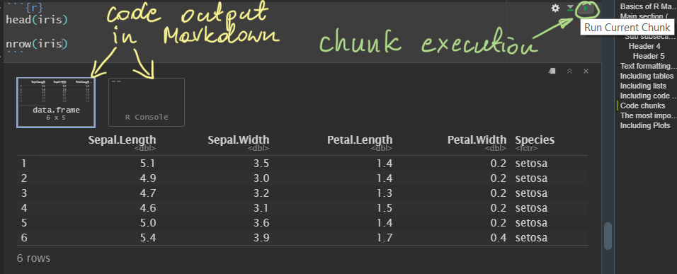

Code output in RMarkdown

> Remember! When Knitting the R Markdown document, R is running all the chunks included inside (unless specified otherwise). Even if the execution will be failed in just one code chunk (because of an error or missing package) - the knitting will stop and the final document will not be generated. In that case you need to come back to the document, improve your code and start the knitting again.

Another painful situation may happen if your code (included in the report) runs for a very long time. This means that the knitting (which triggers all the code chunks to execute consecutively) will be extremely time-consuming as well.

The usual example is for creating machine learning reports, which include comparisons of many time-consuming models and big datasets. In this case it may be helpful to prerun the code in a script, save the results of the models to .RData files and then just load them into the memory while knitting the R Markdown, instead of creating them again in the report.

For this to work elegantly you will need to do the following steps:

- put all the codes necessary for creating your model(s) in the report
- make the code chunks that include these codes inactive (so that they will not be executed during the knitting)
- include “supporting chunks” which will load the necessary (model) objects from .RData files
- hide the “supporting chunks” so that they will not be visible in the output file (final report)

In order to do these steps we need to know some additional options which control the code chunks.